# Federalism

POLS 2311: Government of the United States

## Agenda

- Federalism: Definition and Characteristics
- Federalism and the Constitution
- The Evolution of Federalism
- *Laboratories of Democracy*

# Federalism and Division of Power

## Federalism Defined

> *A form of government in which different levels of government act relatively autonomously and have the power to act directly on people within their jurisdictions*

## Federalism Characteristics

- Two levels of government: National (Federal) and subnational (State)
- Written national constitution that can not be changed without the consent of the subnational governments
- Allocate legislative, judicial, and executive authority to the two levels in a way that provides for some autonomy
- Interaction occurs between levels of government
- National courts resolve disputes between levels of government
- Subnational governments represented in the upper chamber of the national legislature (Senate)

## Types of Systems

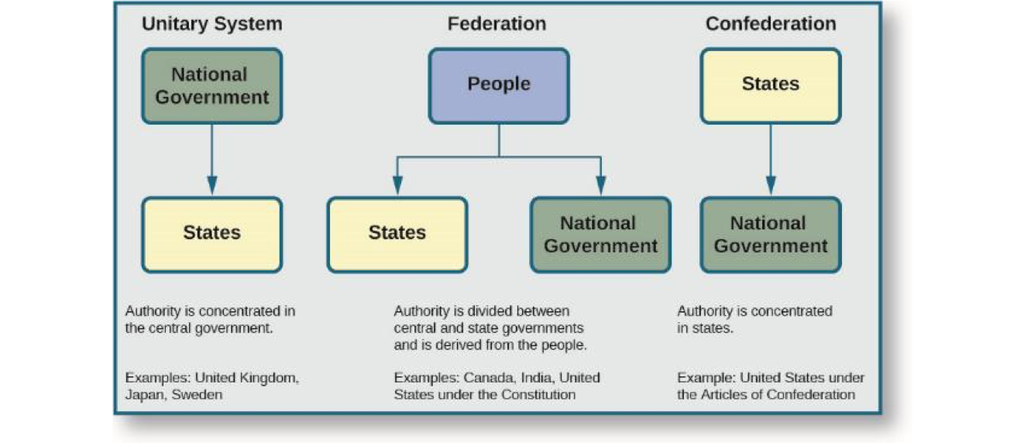

## Types of Systems

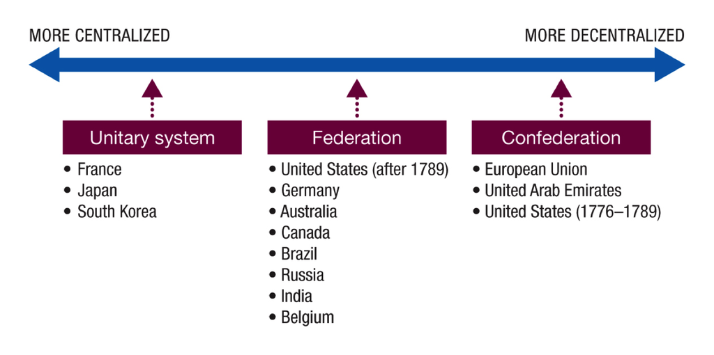

## Types of Systems

- **Unitary systems**: national government holds virtually all power except those powers granted to subnational governments by the central government
  - *Examples*: United Kingdom, France, Japan
- **Confederate systems**: most power is decentralized and possessed by the subnational governments, the central government’s power relies on the consent of the subnational governments
  - *Examples*: the U.S. under the Articles of Confederation, the European Union
- **Federal systems**: national and state governments share sovereignty, and both act directly on citizens
  - *Examples*: United States (since 1789), Canada, Germany, Australia, India

## Why Federalism?

- The founders divided power between federal and state governments to **protect liberty** by limiting central control
- American federalism was a genuinely new design — authority derives from **the people**, not from the states as sovereign contracting parties
- Also intended to provide **balance** between national and state power, and to reduce the danger of *tyranny of the majority*

# Federalism and the Constitution

## Shared Powers

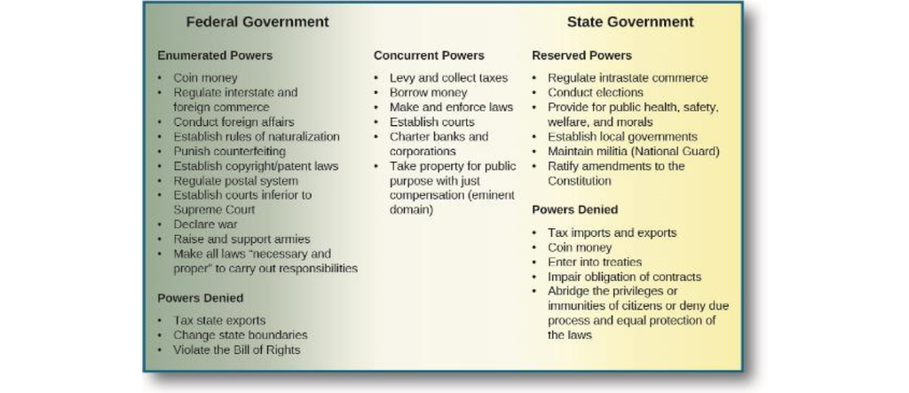

## Necessary and Proper Clause

- Article I, Section 8, Clause 18 states that Congress also has the power *to make all Laws which shall be necessary and proper for carrying into Execution the foregoing Powers, and all other Powers vested by this Constitution in the Government of the United States*
- This clause, known as the *Elastic Clause* or the *Necessary and Proper Clause*, **grants Congress extensive authority to act in the furtherance of its enumerated powers**
  - Courts have taken a particularly broad view of the federal government to act under the *Commerce Clause*, which grants Congress the power to regulate interstate commerce

## Reserved Powers of States

- **Reserved powers**: all powers not prohibited to the states by the Constitution or delegated to the national government
- The Tenth Amendment enshrines the reserved powers of states

## Restrictions on State Power

- Article I, Section 10 restricts the power of the states to act within certain areas, including:
  - entering into treaties with foreign governments
  - coining money
  - levying taxes on imports or exports
  - suspending the writ of habeas corpus, passing bills of attainder, or passing ex post facto laws

## Further Restrictions on State Power

- Several constitutional amendments also include important restraints of state power:
  - The Fourteenth Amendment prohibits states from denying individuals rights granted to them under the U.S. Constitution
  - The Fifteenth, Nineteenth, and Twenty-Sixth Amendments also include important protections of individual civil rights, including a prohibition on state governments (and the federal government) from abridging the right of citizens to vote based on race, sex, or age

## Supremacy Clause

- The **Supremacy Clause** (Article VI, Clause 2) states that the Constitution, federal laws, and treaties are the *supreme Law of the Land*
  - U.S. Constitution, federal law, and treaties prevail over a conflicting state law

# The Evolution of Federalism

## Federal Power

- Federal government power grew in the early 1800s
- Supreme Court’s expansive interpretation of the Elastic (or Necessary and Proper) Clause of the U.S. Constitution, particularly as it applied to the power of Congress to regulate interstate commerce
- States sought to curb the growing power of the national government by asserting *nullification* — the doctrine that a state could declare a federal law null and void
  - Used historically in opposition to tariffs and to slavery
  - Never accepted by federal courts, and definitively settled by the Civil War

## Slavery

- The greatest conflict between national and state power was over the issue of slavery, which culminated in the U.S. Civil War
- The victory of Union forces shifted the balance of power between national and state governments
  - After the Civil War, states no longer asserted a perceived right to challenge constitutionally enacted federal laws
  - As a condition of readmission to the Union, Congress required ratification of the Fourteenth and Fifteenth Amendments by each state that had seceded; these amendments defined the citizenship and rights of freed slaves

## Types of Federalism

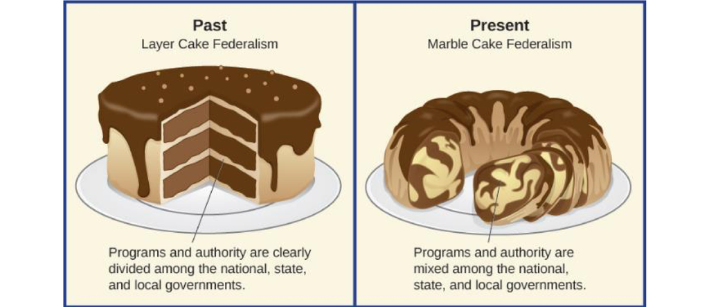

## Types of Federalism

- **Dual federalism**: a political arrangement in which the national government and state governments act with distinct areas of jurisdiction
  - The dominant model from the founding through the early 20th century — the “layer cake”
- **Cooperative federalism**: the national and state governments coordinated their efforts to address problems
  - economic regulation, civil rights protection, the creation of social welfare programs to benefit the elderly and disabled, environmental protection, and the promotion of urban renewal and affordable housing
  - the New Deal (1930s) and the Great Society (1960s) — the “marble cake”

## Regulatory Federalism

- **Regulatory federalism** (1970s–present): the federal government increasingly shapes state behavior through **mandates** and **funding conditions** rather than cooperation alone
  - Federal rules on environmental standards, workplace safety, education, and highway funding tie compliance to dollars

## Devolution and New Federalism

- **Devolution**: The transfer of power from the national government to state and local governments
- **New federalism**: decentralizing national power, increasing revenue sharing with state and local governments, and giving greater discretion to state and local governments over spending federal grants
  - Associated with the Reagan administration (1981–1989) and its successors
  - Revives **dual federalism** — the “layer cake” — as a normative ideal

## Categorical vs. Block Grants

- **Grants-in-aid**: money the national government gives to the states
  - Cash grants-in-aid predate 1808 but remained few and small until the 20th century; today federal grants fund hundreds of programs
- **Categorical grants**: tied to narrowly defined programs — allow greater federal oversight
- **Block grants**: broader discretion — put allocation decisions closer to the people and the issue
  - Central to the devolution debate: New Federalism sought to replace categorical grants with block grants
- Federal aid often comes with **conditions of aid** and sometimes outright **mandates** — both politically controversial over cost of implementation and conflict with state cultural preferences

## Federal Grants by Purpose

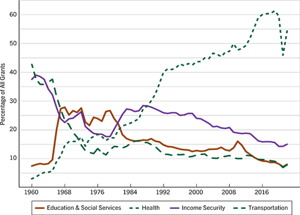

## Laboratories of Democracy

- Justice Louis Brandeis, *New State Ice Co. v. Liebmann* (1932, dissent): states should function as **“laboratories of democracy”** — trying new policies while protecting local identity and autonomy
- States implement different policies, and successful ones can spread to other states or to the federal government — an example of **policy diffusion**
- Three mechanisms of direct democracy vary by state:
  - **Initiative**: voters place a proposed law or amendment directly on the ballot
  - **Referendum**: voters reject or approve a measure passed by the legislature
  - **Recall**: voters remove an elected official from office before their term ends